# ¡Bienvenido a Estadística en Acción!

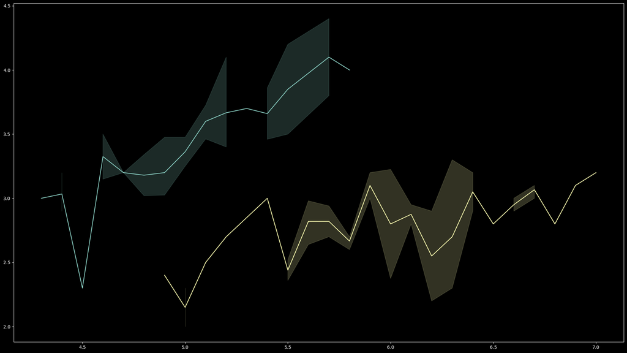

Este es un blog personal dedicado a quienes deseen explorar las numerosas aplicaciones de la matemática, la estadística y la ciencia de datos. A través de esta página, publicaré artículos relacionados con estos temas y también compartiré algunos de mis proyectos personales.

Basado fundamentalmente en Jupyter Lab, en este espacio no solo expondré temas, métodos y modelos teóricos con ejemplos, sino que también mostraré implementaciones computacionales principalmente en R, MariaDB y Python.

Espero les guste.

## Artículo más Reciente

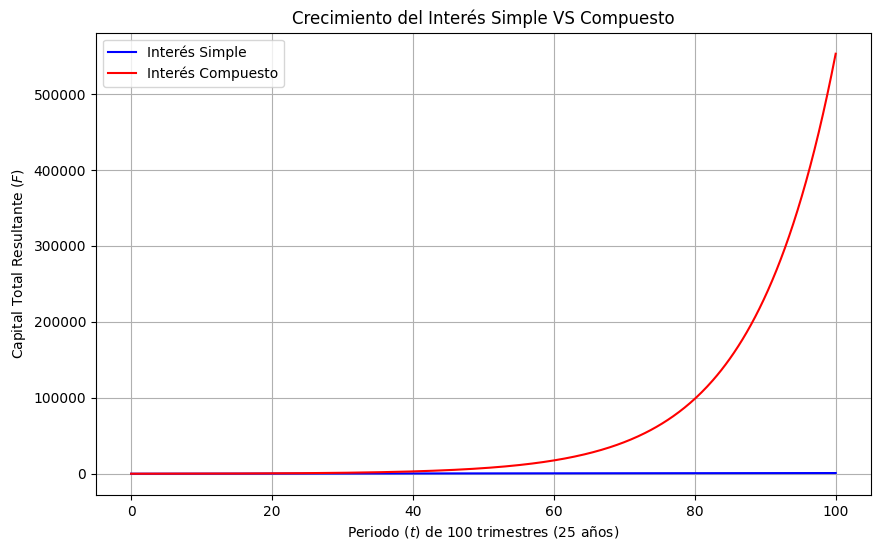

### Teoría del Interés I:

En este artículo, trato las aplicaciones del valor del dinero en el tiempo para una tasa de interés fija. Abordo la función de acumulación, el interés simple, el interés compuesto y el valor presente para ambos tipos…… Leer más

## Proyecto más Reciente:

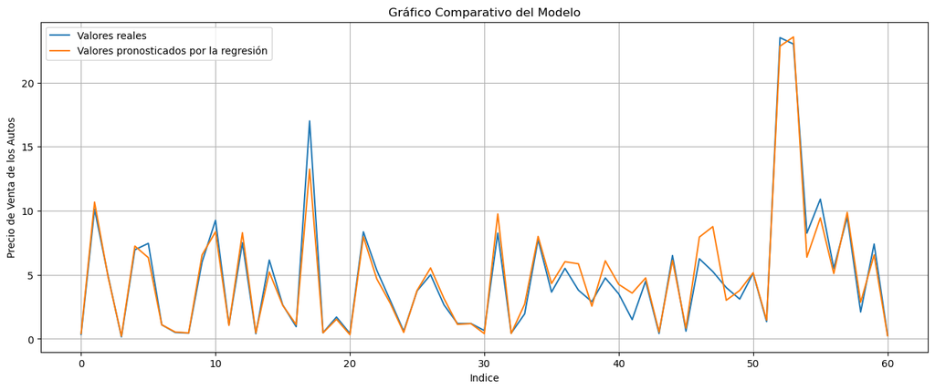

### Predicción de Precios utilizando Bosque Aleatorio:

En este proyecto, buscamos construir un modelo de pronóstico para los precios de venta de autos en un concesionario de la India, a partir de otros datos del concesionario y de los propios autos. Dicho modelo se basa en una regresión de bosque aleatorio, que es un bagging o bootstrap del método de regresión de árboles de decisión. Haz click aquí para ver el proyecto

## Lista de Anexos:

### Anexo: Demostración de la Muestra y Varianza Normal

Demostración de la media y la varianza de la distribución normal son los respectivos parámetros, a partir de la sus definiciones dadas por la esperanza matemática. Ver anexo